# Bayesian Observational Study Design

I've been reading through [Causal Inference: The Mixtable](https://mixtape.scunning.com/) which describes a variety quasi-experimental designs that attempt to estimate causal effects from observational studies. The book uses a frequentist approach, however; I wondered whether a Bayesian methodology might work as well. Specifically, each of these quasi-experimental designs corresponds to different assumptions about the generative process that led our observations of the treatment and control groups. By making these assumptions explicit, we can transfer these causal inference tools to the Bayesian setting, reaping the benefits of improved uncertainty estimation and greater control when incorporating prior knowledge.

I will use the `numpyro` probabilistic programming library to showcase these designs. It's substantially faster than `pymc3`, but has a syntax far less verbose than `Stan` and still integrates well with python's `arviz` library for bayesian data analysis.

## Import Statements

To allow `numpyro` to access multiple CPUs during sampling, we need to run the following command before importing `jax`.

```python
import numpyro
numpyro.set_host_device_count(4)
```

From here, we can continue importing other useful parts of numpyro.

```python
import numpyro.distributions as dist
from numpyro.infer import MCMC, NUTS, Predictive
from numpyro import handlers
from numpyro.contrib.hsgp.laplacian import eigenfunctions
from numpyro.contrib.hsgp.spectral_densities import (
    diag_spectral_density_squared_exponential,
)
```

Numpyro builds on the `jax` ecosystem.

```python
import jax
import jax.numpy as jnp
```

We'll use pieces of python's standard data analysis tools as well.

```python
import pandas as pd
import numpy as np
import arviz as az
import xarray as xr
import preliz as pz
from collections import namedtuple
import seaborn as sns
import matplotlib.pyplot as plt
```

```python
import warnings
warnings.filterwarnings('ignore')
```

## Convenience Functions

As I'm attempting to replicate the examples in the *Mixtape* book, I'll use the datasets Scott provides. These are downloaded as follows:

```python
import ssl
ssl._create_default_https_context = ssl._create_unverified_context
```

```python
def read_data(file):
    return pd.read_stata("https://github.com/scunning1975/mixtape/raw/master/" + file)
```

I'll fit all the models in this post with the no-U-turn sampler.

```python
def fit_nuts(model, *args):
    nuts_kernel = NUTS(model)
    mcmc = MCMC(nuts_kernel, num_warmup=500, num_samples=1000, num_chains=4)
    mcmc.run(jax.random.PRNGKey(0), *args)
    return mcmc
```

It will also be convenient to get samples from the prior and posterior predictive distributions to check if our inference results make sense. The following wraps these samples into an arviz `InferenceData` object.

```python
def from_numpyro(model, mcmc, *args):
    post_pred = Predictive(model, mcmc.get_samples())(jax.random.PRNGKey(1), *args)
    prior = Predictive(model, num_samples=1000)(jax.random.PRNGKey(2), *args)
    return az.from_numpyro(
        mcmc,
        prior=prior,
        posterior_predictive=post_pred)
```

## A Linear Regression Abstraction for Pyro

Many of the generative models described in *Mixtape* are variations on linear regression. Probabilistic programming languages like Stan and Pymc3 have special DSLs for generalized linear models (bambi and stan_glm respectively). But it's easy enough to throw together something comparable for Pyro. The main utility of these specialized tools is their automatic calculation of [data driven priors](https://mc-stan.org/rstanarm/articles/priors.html). Let $\mu_y$ and $\sigma_y$ be the empirical mean and standard deviation of $y$ respectively. I'll specify default priors as follows:

- Encode categorical variables with $k$ categories as $k-1$ dimensional vectors. Membership in category $0$ corresponds to the zero vector, while membership in category $i$ corresponds to the 1-hot vector at $i$. This lets the $i$th coefficient represent the average change in $y$ we'd see comparing someone in category $i+1$ to category $0$.
- The coefficient for each mean-centered continuous covariate $x$ has a zero mean Gaussian prior with scale $2.5 \sigma_y / \sigma_x$. This is equivalent to standardizing the predictors and letting the scales be $2.5 \sigma_y$. In this case, the cofficients represent the change in $y$ we would get by increasing each covariate by a single standard deviation. Allowing each change in $x$ to produce a change in $y$ covering almost all of the observed variance (2.5 standard deviations) therefore gives us a very weakly informative prior.
- The coefficients for categorical encodings also have zero mean Gaussian priors with scale $2.5 \sigma_y$.
- The scale of the noise is given an Exponential prior with a mean matching the observed standard deviation. We certainly wouldn't expect noise scales larger than this, as regressing on covariates should allow us to *reduce* the variance rather than increasing it.
- The intercept term has a Gaussian prior centered on the observed mean among all observations in the baseline categories, with a scale of $2.5\sigma_y$.

```python
def lm(df: pd.DataFrame, y: str, cats: list[str], xs: list[str], predictive: bool):
    "Regress `y` against the continuous variables in `xs` and categorical variables in `cats`."
    stdy = df[y].std()
    baselines = baseline_mask(df, cats)
    mu = numpyro.sample("intercept", dist.Normal(df.loc[baselines,y].mean(), 2.5 * stdy))
    sigma = numpyro.sample("sigma", dist.Exponential(1 / stdy))
    for x in cats:
        X = dummy_encode(df[x].cat)
        beta = numpyro.sample(f"beta_{x}", dist.Normal(np.zeros(X.shape[1]), 2.5 * stdy))
        mu = mu + jnp.array(X) @ beta
    for x in xs:
        X = df[x].to_numpy()
        stdx = X.std()
        beta = numpyro.sample(f"beta_{x}", dist.Normal(0, 2.5 * stdy / stdx))
        mu = mu + (X - X.mean()) * beta
    numpyro.deterministic("mu", mu)
    return numpyro.sample('y', dist.Normal(mu, sigma), obs=None if predictive else jnp.array(df[y]))
```

```python
def baseline_mask(df: pd.DataFrame, cats: list[str]):
    "Find the elements of `df` which have categorical variables in `cats` at baseline levels."
    mask = np.ones(df.shape[0], dtype=bool)
    for cat in cats:
        mask &= df[cat].cat.codes == 0
    return mask
```

```python
def dummy_encode(cat):
    """
    Encode categorical variables with `k` categories as a `k-1`-element vectors indicating
    deviations from the base category.
    """
    n = len(cat.categories) - 1
    return np.concatenate((np.zeros((1, n)), np.eye(n)), axis=0)[cat.codes]
```

## Difference in Differences

The *Mixtape* book applies this idea to estimate whether the Roe decision in 1973 resulted in decreased teen gonorrhea rates 15 years later (the implication being that mothers forced to bear children they felt ill equipt to raise would see higher gonorrhea rates among their children). The book focuses on the gonorrhea rates of black girls age 15-20 before 1993.

```python
abortion = read_data('abortion.dta')
abortion = abortion[~pd.isnull(abortion.lnr)]
abortion = abortion[(abortion.bf15==1) & (abortion.year <= 1993) & (abortion.age == 15)]
```

We can do a difference-in-differences study here because five states legalized abortion *before* the Roe decision, in 1970. These five states will constitute our first population, and the rest of the states will be our second population. In 1985, none of the teenagers in the 15-20 age group would have been born in a post-legalization world, so this sets the baseline for both populations. In 1986, however, one of the five ages in the first population would be been born post-legalization, so we expect to see some of the treatment effect brought by legalization. By 1991, this entire age group in the first population will represent teens born post-legalization.

The relevant variables here are the log number of new gonorrhea cases in each age group per year ('lnr') and an indicator variable for the group with an earlier legalization year ('repeal'). When we plot the data below, we see a pattern similar to what we expected. The distance between our two groups grew steadily until 1988, at which point their distance slowly converged back to baseline levels.

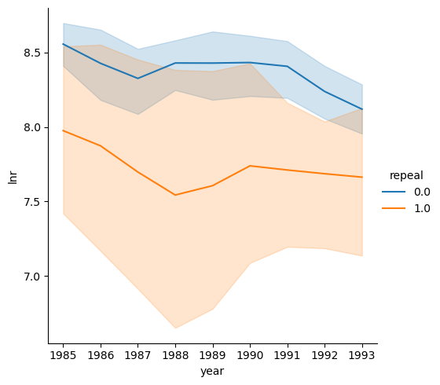

```python
sns.relplot(abortion, x="year", y="lnr", hue="repeal", kind="line");
```

To more accurately quantify this effect, we must first calculate the fraction of 15-20 year olds born after abortion was legalized in their states for each year.

```python
treatment_group = abortion.repeal == 1.0
abortion['treated_frac'] = 0
abortion.loc[treatment_group, 'treated_frac'] = np.minimum(abortion[treatment_group].year - 1970 - 15, 5) / 5
abortion.loc[~treatment_group, 'treated_frac'] = np.minimum(abortion[~treatment_group].year - 1973 - 15, 5) / 5
```

Then, we'll tell pandas to treat the year and group as categorical variables.

```python
abortion['repeal'] = pd.CategoricalIndex(abortion.repeal)
abortion['year'] = pd.CategoricalIndex(abortion.year)
```

After this preprocessing, the difference-in-differences model comes down to a simple linear regression.

```python
def abortion_model(predictive):
    lm(abortion, 'lnr', ['repeal', 'year'], ['treated_frac'], predictive)
```

```python
mcmc = fit_nuts(abortion_model, False)
```

Unfortunately, this model isn't a great representation of the underlying data. The residuals don't look particularly normal:

```python
residuals = (mcmc.get_samples()["mu"] - abortion['lnr'].to_numpy()[None, :]).mean(axis=0)
```

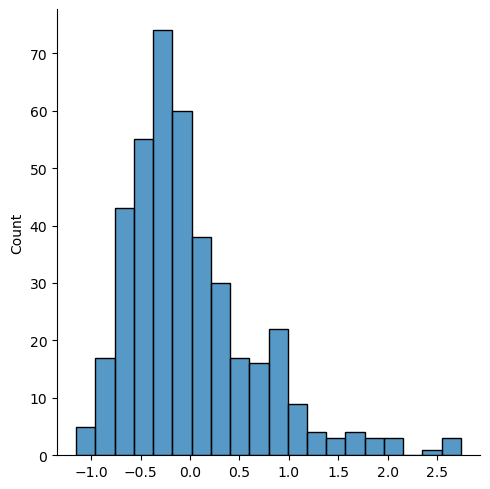

```python
sns.displot(residuals)
```

The observations also aren't particularly likely according to the posterior predictive distribution.

```python
abortion_results = from_numpyro(abortion_model, mcmc, True)
```

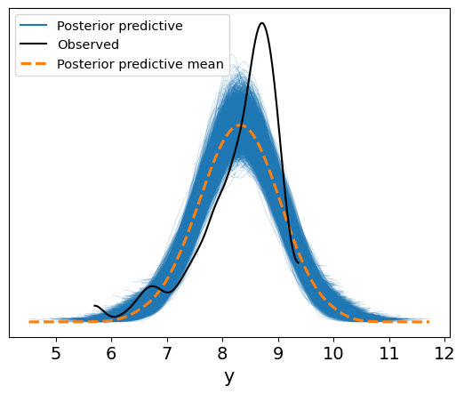

```python
az.plot_ppc(abortion_results, var_names='y');
```

Observations aren't even uniformly unlikely.

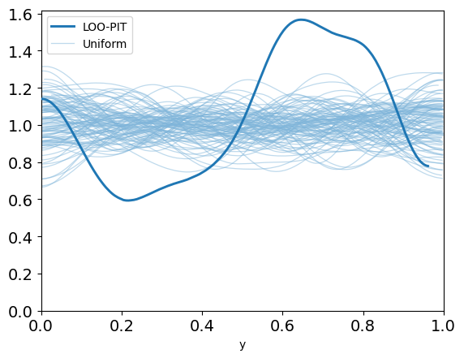

```python
az.plot_loo_pit(abortion_results, y="y")
```

So it seems we might need to come up with something a little more detailed than the simple linear model implied by the Difference-in-Differences design.

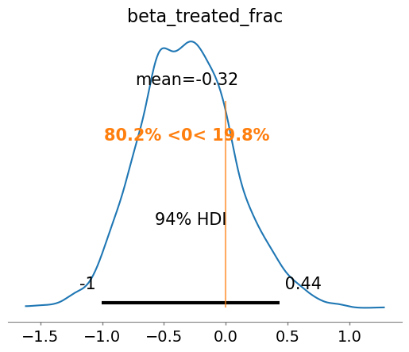

```python
az.plot_posterior(abortion_results, "beta_treated_frac", ref_val=0.0);
```

## Syntheic Control

The synthetic control design resembles difference-in-differences, but instead of comparing a treatment population against a single baseline, syntheic control compares against a mixture of baselines. The mixture weights are chosen to make the mixture's observations match the treatment population's observations before treatment.

The *Mixtable* book uses a synthetic control design to study whether Texas's prison building boom in 1993 resulted in them incarcerating more prisoners than they would have if their rate of prison building had continued as normal. We'll express Texas's incarceration rates over time as a mixture of those of other states. Then, we'll use this mixture of other states to construct a "synthetic" counterfactual Texas which, like the states in the mixture, didn't have a prison building boom in '93. We can compare the difference between the true and synthetic Texas over time.

```python
texas = read_data("texas.dta")
```

Our endogenous variable $y$ will be the incarceration rate per 100k people.

```python
texas['incarceration_rate'] = texas.bmprison / (texas.bmpop / 100_000)
```

Looking at the data shows a pretty sizeable increase in Texas's incarceration rate after '93 compared to other states, which lends credence to the hypothesis.

```python
years = pd.unique(texas.year)
```

```python
all_rates = np.reshape(texas[texas.state != "Texas"].sort_values(["state", "year"]).incarceration_rate.values, (50, -1))
```

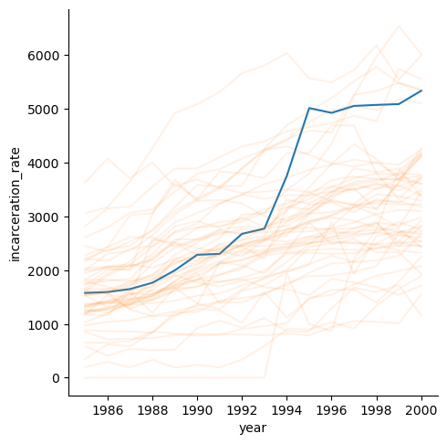

```python
sns.relplot(texas[texas.state == "Texas"], x="year", y="incarceration_rate", kind="line");
for r in all_rates:
    plt.plot(years, r, color="C1", alpha=0.1)
```

We'll chose our mixture weights to combine other states into a synthetic Texas with matching poverty, alcoholism and incarceration rates during the period before 1993. $X$ will be a $S \times T \times K$ matrix where $S$ is the number of states (other than Texas), $T$ is the number of observed pre-treatment years and $K$ is the number of covariates to be matched.

```python
def synth_control(y):
    w = numpyro.sample("w", dist.Dirichlet(jnp.ones(50)))
    with numpyro.plate("covariate", X.shape[-1]):
        sigma = numpyro.sample("sigma", dist.Exponential(1 / stds))
        with numpyro.plate("pre_treatment_year", X.shape[-2]):
            numpyro.sample("pre_treatment_obs", dist.Normal(loc=(X.T @ w).T, scale=sigma), obs=y)
    with numpyro.plate("all_years`", test_X.shape[-1]):
        yhat = numpyro.deterministic("yhat", (w @ test_X))
```

To construct $X$, we will use a convenience function that converts a dataframe to a multidimensional array for which every dimension but the last enumerates possible values of a different covariate.

```python
def grouped_array(df, mask, covariates, groups):
    filtered = df.loc[mask, groups + covariates]
    grouped = filtered.groupby(groups).mean()
    dims = [len(pd.unique(filtered[g])) for g in groups]
    return jnp.array(np.reshape(grouped.values, [*dims, -1]))
```

```python
covariates = ["poverty", 'incarceration_rate', 'alcohol']
```

```python
X = grouped_array(texas, (texas.state != "Texas") & (texas.year < 1993),  covariates, ["state", "year"])
```

We can use the same function to compute the covariate values our synthetic Texas should obtain for the pre-treatment years.

```python
y = grouped_array(texas, (texas.state == "Texas") & (texas.year < 1993), covariates, ["year"])
```

```python
test_X = grouped_array(texas, (texas.state != "Texas"),  ["incarceration_rate"], ["state", "year"]).squeeze()
```

We'll use the same uninformative prior for the noise that we used in the linear regression model defined previously.

```python
stds = jnp.array(texas.loc[texas.year < 1993, ["year", *covariates]].groupby("year").std().mean().values)
```

Fitting the model lets us plot the incarceration rate for our counterfactual "synthetic" version of Texas.

```python
mcmc = fit_nuts(synth_control, y)
```

```python
samples = mcmc.get_samples()
```

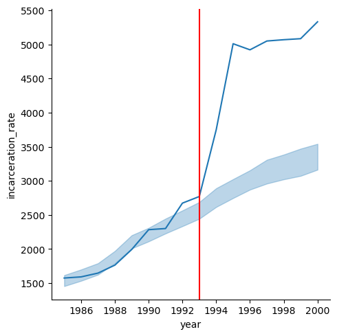

```python
sns.relplot(texas[texas.state == "Texas"], x="year", y="incarceration_rate", kind="line");
az.plot_hdi(years, samples['yhat'][None,:,:], color='C0', smooth=False, fill_kwargs={"alpha": 0.3})
plt.axvline(x=1993, c='red');
```

This "synthetic" Texas has highest mixture weights for other southern states, but generally seems to spread the weight pretty evenly around.

```python
mean_ws = samples['w'].mean(axis=0)
std_ws = samples['w'].std(axis=0)
mean_ixs = np.argpartition(mean_ws, -3)[-3:]
list(zip(states[mean_ixs], mean_ws[mean_ixs]))
```

```
[('Arkansas', Array(0.02952166, dtype=float32)),
 ('Mississippi', Array(0.03818997, dtype=float32)),
 ('Louisiana', Array(0.05022292, dtype=float32))]
```

Unlike the difference in differences model above, this model describes the underlying dynamics reasonably well; the posterior predictive checks look good.

```python
texas_results = from_numpyro(synth_control, mcmc, None)
```

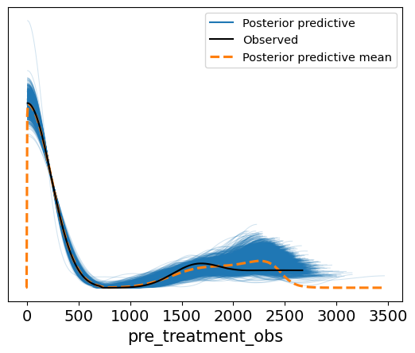

```python
az.plot_ppc(texas_results, var_names='pre_treatment_obs');
```

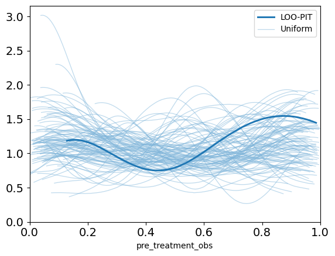

```python
az.plot_loo_pit(texas_results, y="pre_treatment_obs")
```

## Better Numpyro Gaussian Processes

For other quasi-experimental designs, we're going to use Gaussian processes. Numpyro has some support for Gaussian processes including support for the Hilbert space approximation, but the standard interface makes it difficult to evaluate the same latent function on multiple sets of points within a model. The code below provides a nicer interface to the same functionality. Note that I am using [Brendan Cooley's](https://github.com/brendancooley/numpyro/tree/feat/hsgp/vector-valued-kernel-hyparams) fork of Numpyro, which adds support for vector valued HSGPs.

```python
class hsgp(namedtuple("hsgp", "spd beta ell m")):
    __slots__ = ()
    def at(self, x):
        phi = eigenfunctions(x=x, ell=self.ell, m=self.m)
        return phi @ (self.spd * self.beta)
```

```python
def hsgp_rbf(
    prefix: str,
    alpha: float,
    ell: float,
    m: int,
    length: jax.Array) -> jax.Array:
    spd = jnp.sqrt(diag_spectral_density_squared_exponential(
            alpha=alpha, length=length, ell=ell, m=m, dim=len(length)))
    with handlers.scope(prefix=prefix):
        with numpyro.plate("basis", len(spd)):
            beta = numpyro.sample("beta", dist.Normal())
    return hsgp(spd, beta, ell, m)
```

We'll generally be using RBF kernels which require a lengthscale parameter. We'll specify a loose prior over lengthscales wide enough to account for any of the distances observed in the data.

```python
def lengthscale_params(xs):
    x_vals = xs.to_numpy()
    differences = np.abs(np.subtract.outer(x_vals, x_vals))
    nz = differences[differences != 0]
    l_b = np.quantile(nz, 0.025)
    u_b = np.quantile(nz, 0.975)
    dist = pz.InverseGamma()
    pz.maxent(dist, l_b, u_b, 0.95, plot=False)
    return dist.params
```

## Matching Model

The 'matching' design controls for confounder variables $x$ by estimating what the control outcomes $y$ would be if the control population had the same values of $x$ as the treatment population. To do this, we regress outcomes in the control population on $x$, and apply this regression model to the treatment population's confounder distribution.

```python
def matching_model(param):
    with numpyro.plate("ldim", param.l[0].shape[0]):
        l = numpyro.sample("l", dist.InverseGamma(*param.l))
    alpha = numpyro.sample("alpha", dist.HalfNormal(param.s))
    sigma = numpyro.sample("sigma", dist.HalfNormal(param.s))
    f = hsgp_rbf("f", length=l, alpha=alpha, m=15, ell=param.ell)
    numpyro.sample("y0", dist.Normal(loc=f.at(param.control_x), scale=sigma), obs=param.y0)
    numpyro.deterministic("effect", param.y1.mean() - f.at(param.treated_x).mean())
```

```python
gp_param = namedtuple("gp_param", "control_x treated_x l s y0 y1 ell")
```

```python
def assemble_param(df, treated, xs, y):
    control = df[~df[treated]]
    l = np.array([lengthscale_params(control[x]) for x in xs]).T
    s = control[y].std()
    treatment = df[df[treated]]
    ell = 1.2 * df[y].abs().max()
    y0 = jnp.array(control[y].to_numpy())
    y1 = jnp.array(treatment[y].to_numpy())
    return gp_param(jnp.array(control[xs].to_numpy()), jnp.array(treatment[xs].to_numpy()), l, s, y0, y1, ell)
```

The *Mixtape* book demonstrates this design by estimating the effect on fugure earnings of attending a job training program, specifically the National Supported Work Demonstration program established by the US government in the '70s. It compares changes in earnings for those who enrolled in the program to changes in earnings of the general US population as reported by the Current Population Survey. By using the matching model above, we can control for the fact that those who enrolled in the program were generally less educated and younger than the overall population.

```python
cps = read_data("cps_mixtape.dta")
nsw = read_data("nsw_mixtape.dta")
nsw = pd.concat([nsw, cps])
nsw['treated'] = nsw.treat == 1.0
nsw['improvement'] = nsw.re78 - nsw.re75
```

```python
param = assemble_param(nsw, 'treated', ['educ', 'age'], 'improvement')
```

```python
mcmc = fit_nuts(matching_model, param)
```

```python
results = from_numpyro(matching_model, mcmc, param._replace(y0=None))
```

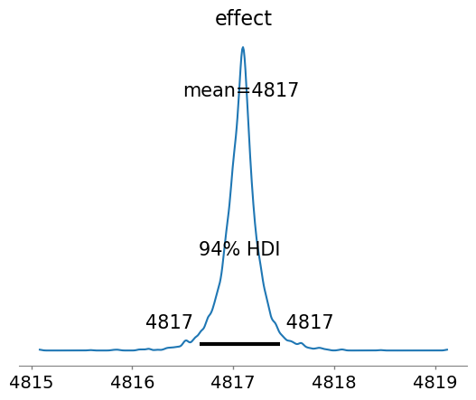

```python
az.plot_posterior(results, var_names="effect");
```

The matching model estimates that the job training program led to $4817 in additional inflation adjusted earnings, which is higher than a naive difference of means would suggest.

```python
(nsw[nsw.treated]['improvement']).mean() - (nsw[~nsw.treated]['improvement']).mean()
```

```
3397.8271
```

Unfortunately, the current GP model doesn't fit the control data very well. One important difference between the two is a large spike of people who saw no change in income during the measured three year period. A more sophisticated model might use a mixture to capture this discrepency. We also might want to take other measured variables such as race and marital status into account. These are, however, beyond the scope of this example.

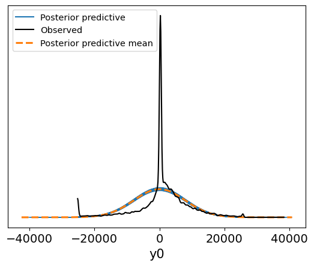

```python
az.plot_ppc(results, var_names='y0');
```

## Regression Discontinuity

The Regression Discontinuity design is similar to the matching approach above. Instead of looking at the average difference between treated and untreated $y$ values across the control's $x$s, however, we estimate the difference between treated and untreated $y$ values at a single point $x^*$. In this design, we assume that treatment is automatically applied whenever $x$ is above $x^*$, and we're interested in the effect of treatment at this cutoff point. We'll fit separate GPs to the observations of the treatment and control groups. Then, we'll compare what these two GPs predict at $x*$.

Instead of using data from the *Mixtape* book here, I'll use a synthetic example more amenable to visualization.

```python
rd = pd.read_pickle("rd.pkl")
```

Here, we assume that at $x \geq 0.5$, a treatment is applied that tends to increase values of $y$. If the treatment had not been applied, we assume that $y$ would have continued to change as a smooth function of $x$ rather than displaying the sharp discontinuity observed.

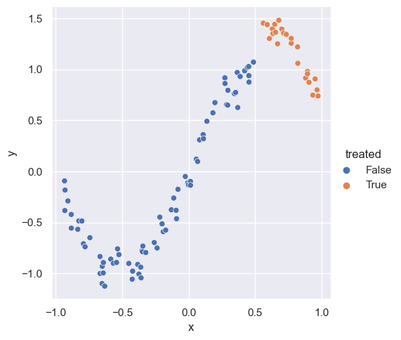

```python
sns.relplot(rd, x='x', y='y', hue='treated');
```

```python
def regression_discontinuity(param):
    with numpyro.plate("ldim", param.l[0].shape[0]):
        l = numpyro.sample("l", dist.InverseGamma(*param.l))
    alpha = numpyro.sample("alpha", dist.HalfNormal(param.s))
    sigma = numpyro.sample("sigma", dist.HalfNormal(param.s))
    f0 = hsgp_rbf("f0", length=l, alpha=alpha, m=15, ell=param.ell)
    f1 = hsgp_rbf("f1", length=l, alpha=alpha, m=15, ell=param.ell)
    numpyro.sample("y0", dist.Normal(loc=f0.at(param.control_x), scale=sigma),
        obs=param.y0)
    numpyro.sample("y1", dist.Normal(loc=f1.at(param.treated_x), scale=sigma),
        obs=param.y1)
    numpyro.deterministic("effect", f1.at(jnp.array([0.5])) - f0.at(jnp.array([0.5])))
    numpyro.deterministic("f0test", f0.at(test0))
    numpyro.deterministic("f1test", f1.at(test1))
    numpyro.deterministic("f0zoom", f0.at(zoom0))
    numpyro.deterministic("f1zoom", f1.at(zoom1))
```

```python
test0 = jnp.linspace(-1.0, 0.5, 100)
test1 = jnp.linspace(0.5, 1.0, 100)
zoom0 = jnp.linspace(0.4, 0.5, 100)
zoom1 = jnp.linspace(0.5, 0.6, 100)
```

```python
param = assemble_param(rd, 'treated', ['x'], 'y')
```

```python
mcmc = fit_nuts(regression_discontinuity, param)
```

```python
results = from_numpyro(regression_discontinuity, mcmc, param)
```

The effect is small, but almost certainly positive.

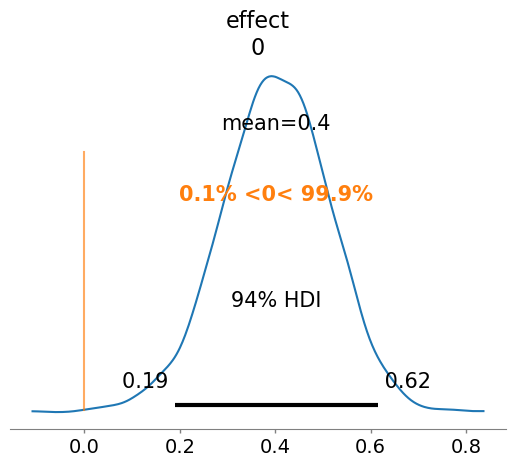

```python
az.plot_posterior(results, var_names="effect", ref_val=0.0);
```

We can visualize the separate GPs fit for the control and treatment groups.

```python
samples = mcmc.get_samples()
```

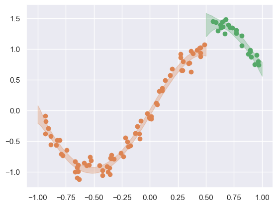

```python
fig, ax = plt.subplots()
az.plot_hdi(test0, samples['f0test'][None,...], color='C1', smooth=False, fill_kwargs={"alpha": 0.3}, ax=ax)
ax.scatter(df.x[df.treated], df.y[df.treated], color='C2')
ax.scatter(df.x[~df.treated], df.y[~df.treated], color='C1')
az.plot_hdi(test1, samples['f1test'][None,...], color='C2', smooth=False, fill_kwargs={"alpha": 0.3}, ax=ax);
```

To get a better picture of the treatment effect, we can zoom in on $x=0.5$. The distance between the shaded regions lower bounds our causal effect estimate.

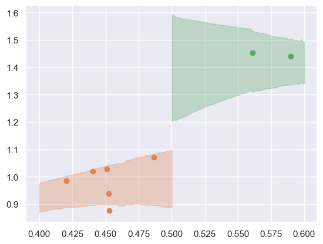

```python
fig, ax = plt.subplots()
az.plot_hdi(zoom0, samples['f0zoom'], color='C1', smooth=False, fill_kwargs={"alpha": 0.3}, ax=ax)
mask = rd.x.between(0.4, 0.6)
ax.scatter(rd.x[mask & rd.treated], rd.y[mask & rd.treated], color='C2')
ax.scatter(rd.x[mask & ~rd.treated], rd.y[mask & ~rd.treated], color='C1')
az.plot_hdi(zoom1, samples['f1zoom'], color='C2', smooth=False, fill_kwargs={"alpha": 0.3}, ax=ax);
```